# Práctica 13. Aplicaciones relacionadas a la demografía (IV)

Ana Escoto

14/01/2021

# Previo

## Paquetería

```r
#install.packages("collapse")
if (!require("pacman")) install.packages("pacman") # instala pacman si se requiere
```

```r
pacman::p_load(tidyverse,
               readxl,writexl, # importar hojas de cálculo
               haven, foreign, # importación de dta y sav
               janitor, skimr, #limpieza y verificación
               imputeTS, # para imputar valores
               esquisse, # para usar ggplot de manera más amigable
               demography) # para tabla de vida
```

## Directorio

En caso que no tengas un proyecto,establecer el directorio puede ayudar

```r
rm(list=ls()) # mala práctica pero quizás necesaria porque vamos a cambiar de tema
setwd("/Users/anaescoto/Dropbox/2020/2021-1 R para Demográfos/repo/R_Demo")
```

# Construcción de la tabla de vida

Código para revisar algunos elementos de Mortalidad en México Parte de este código está tomado de acá http://www.ub.edu/rfa/R/life_tables.html

## Insumo 1. Población expuesta al riesgo

Nuestros denominadores es la población al 1 de julio, proyectada por Conapo Contiene 1950-2050 para República Mexicana

La edad es singular Debemos llegar al formato de HMD para que el paquete demography lo lea correctamente

### Importar desde CONAPO

Necesitamos para aproximarnos al tiempo vivido, la población a mitad del año. Esto lo podemos importar con el siguiente código.

```r
pob_1jul0 <- read_csv("https://github.com/aniuxa/R_Demo/raw/master/datos/pob_mit_proyecciones.csv",
                     locale = locale(encoding = "latin1"))
```

Vamos a limpiar los nombres

```r
pob_1jul0<-clean_names(pob_1jul0) #limpia los nombres
```

### Dar formato a la información

Los siguientes códigos sirven para poner esta información en formado de la HMD (por ejemplo: http://www.ub.edu/rfa/R/Exposures_1x1SPAIN.txt )

```r
pob_1jul0<-pob_1jul0 %>%
  select(-renglon) %>%  #quita la variable renglón
  filter(cve_geo==0) %>% # selecciona la República Mexicana, si se quiere otro estado se puede modificar
  select(-c(entidad,cve_geo)) # quita estas variables que no están en el formato

pob_1jul0
```

```
## # A tibble: 22,220 x 4
##      ano  edad sexo    poblacion
##    <dbl> <dbl> <chr>       <dbl>
##  1  1950     0 Hombres    572103
##  2  1950     0 Mujeres    559162
##  3  1950     1 Hombres    514540
##  4  1950     1 Mujeres    505269
##  5  1950     2 Hombres    478546
##  6  1950     2 Mujeres    469322
##  7  1950     3 Hombres    451932
##  8  1950     3 Mujeres    442707
##  9  1950     4 Hombres    430010
## 10  1950     4 Mujeres    420903
## # … with 22,210 more rows
```

Para parecerse más a nuestro formato, vamos usar un pivot_wider:

```r
pob_1jul_sex<-pob_1jul0 %>%
  pivot_wider(names_from = sexo, values_from = poblacion) ## Ordena por sexo
pob_1jul_sex
```

```
## # A tibble: 11,110 x 4
##      ano  edad Hombres Mujeres
##    <dbl> <dbl>   <dbl>   <dbl>
##  1  1950     0  572103  559162
##  2  1950     1  514540  505269
##  3  1950     2  478546  469322
##  4  1950     3  451932  442707
##  5  1950     4  430010  420903
##  6  1950     5  411198  402293
##  7  1950     6  394520  385903
##  8  1950     7  379508  371222
##  9  1950     8  366786  358817
## 10  1950     9  355002  347353
## # … with 11,100 more rows
```

Nos faltan los totales:

```r
pob_1jul_tot<-pob_1jul0 %>%
  group_by(ano, edad) %>%
  tally(poblacion) %>%
  rename(Total=n) # genera el total

pob_1jul_tot
```

```
## # A tibble: 11,110 x 3
## # Groups:   ano [101]
##      ano  edad   Total
##    <dbl> <dbl>   <dbl>
##  1  1950     0 1131265
##  2  1950     1 1019809
##  3  1950     2  947868
##  4  1950     3  894639
##  5  1950     4  850913
##  6  1950     5  813491
##  7  1950     6  780423
##  8  1950     7  750730
##  9  1950     8  725603
## 10  1950     9  702355
## # … with 11,100 more rows
```

Juntamos y pues, renombramos

```r
pob_1jul<-inner_join(pob_1jul_sex, pob_1jul_tot, by=c("ano", "edad")) # fusionamos los dos objetos

names(pob_1jul)<-c( "Year",  "Age", "Male", "Female","Total") # ponemos los nombres
```

Podríamos haber hecho la suma, pero piensa que a veces hay no especificados en sexo.

Un elemento fundamental del formato de HMD es que los datos existen hasta la edad “110+”. El formato de CONAPO sólo tiene hasta 109. Por ello tenemos que agregar estas líneas. De lo contario no se pueden importar:

```r
ages<-as.data.frame(1950:2050)
names(ages)<-"Year"
ages$Age<-110

ages
```

```
##     Year Age
## 1   1950 110
## 2   1951 110
## 3   1952 110
## 4   1953 110
## 5   1954 110
## 6   1955 110
## 7   1956 110
## 8   1957 110
## 9   1958 110
## 10  1959 110
## 11  1960 110
## 12  1961 110
## 13  1962 110
## 14  1963 110
```

[output cut: 87 more lines]

Hacemo un merge:

```r
pob_1jul<-merge(pob_1jul, ages, by=c("Year","Age"), all=T)
```

Finalmente ordenamos la información:

```r
col_order <- c( "Year",      "Age",     "Female", "Male",      "Total")
pob_1jul <- pob_1jul[, col_order]
pob_1jul <-pob_1jul[order(pob_1jul$Year,pob_1jul$Age),]

pob_1jul<-na_replace(pob_1jul, 0) # elimina los missings por ceros
```

## Archivo listo

Finalmente exportamos esto en un formado txt. Este archivo debe estar en nuestro directorio de trabajo, o en nuestro proyecto.

```r
write.table(pob_1jul, file = "exposure.txt", sep = "\t", row.names = F) # exporta el archivo en formato separados por tabs
```

Podemos borrar los objetos que ya no utilizamos

```r
rm(pob_1jul_sex, pob_1jul_tot, pob_1jul0)
```

## Insumo 2 Numeradores - Muertes

### Importar desde Conapo

Al igual que con la población a mitad del año, vamos a importar las defunciones. Es muy parecido así que seremos más escuetos con la descripción:

```r
defunciones0 <-read.csv("https://github.com/aniuxa/R_Demo/raw/master/datos/def_edad_proyecciones_n.csv")

defunciones0<-clean_names(defunciones0)
```

### Dar formato a la información

Los siguientes códigos sirven para poner esta información en formado de la HMD (por ejemplo: http://www.ub.edu/rfa/R/Mx_1x1SPAIN.txt)

```r
defunciones0<-defunciones0 %>%
  select(-renglon) %>%  #quita la variable renglón
  filter(cve_geo==0) %>% # selecciona la República Mexicana, si se quiere otro estado se puede modificar
  select(-c(entidad,cve_geo)) # quita estas variables que no están en el formato

defunciones_sex<-defunciones0 %>%
  pivot_wider(names_from = sexo, values_from = defunciones)

defunciones_tot<-defunciones0 %>%
  group_by(ano, edad) %>%
  tally(defunciones) %>%
  rename(Total=n)

defunciones<-inner_join(defunciones_sex, defunciones_tot, by=c("ano", "edad"))
names(defunciones)<-c( "Year",  "Age", "Male", "Female","Total")
```

Finalmente ordenamos la información

```r
defunciones<-merge(defunciones, ages, by=c("Year","Age"), all=T)
defunciones <- defunciones[, col_order]
defunciones <-defunciones[order(defunciones$Year,defunciones$Age),]

defunciones<-na_replace(defunciones, 0)

rm(defunciones_sex,defunciones_tot, defunciones0)
```

## Cálculo de mx

El segundo insumo nos pide las tasas de mortalidad. Por lo que podemos calcularlas haciendo la división entre nuestros objetos (de ahí que se muy importante haberlo ordenado bien)

```r
mx_mex<-defunciones[,3:5]/pob_1jul[,3:5]
mx_mex<-cbind(defunciones[,1:2], mx_mex)

mx_mex<-na_replace(mx_mex,0)
write.table(mx_mex, file = "mx.txt", sep = "\t", row.names = F)
```

# Leyendo desde demography

Una vez que ya tenemos listos nuestros dos archivos de insumos, podemos leer esta información con el comando read.demogdata().

Revisemos los argumentos:

```r
mex<-read.demogdata("mx.txt",
                    "exposure.txt",
                    type="mortality",
                    label="Mexico",
                    skip=0,
                    popskip = 0,
                    scale=1)
```

Una vez que ya tenemos este objeto, podemos utilizarlo fácilmente en distintos comandos del paquete. Revisaremos un par

## Gráfico de las tasas de mortalidad por sexo

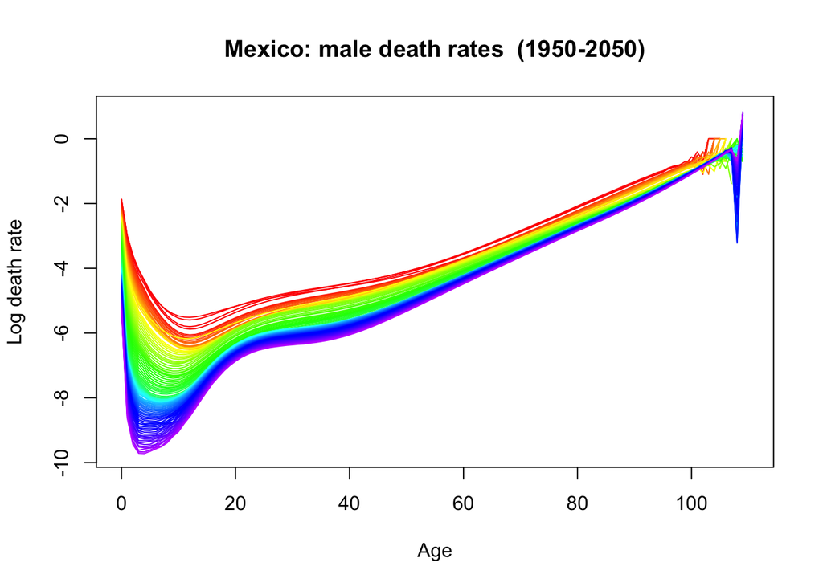

```r
plot(mex,series="Male", plot.type="functions")
```

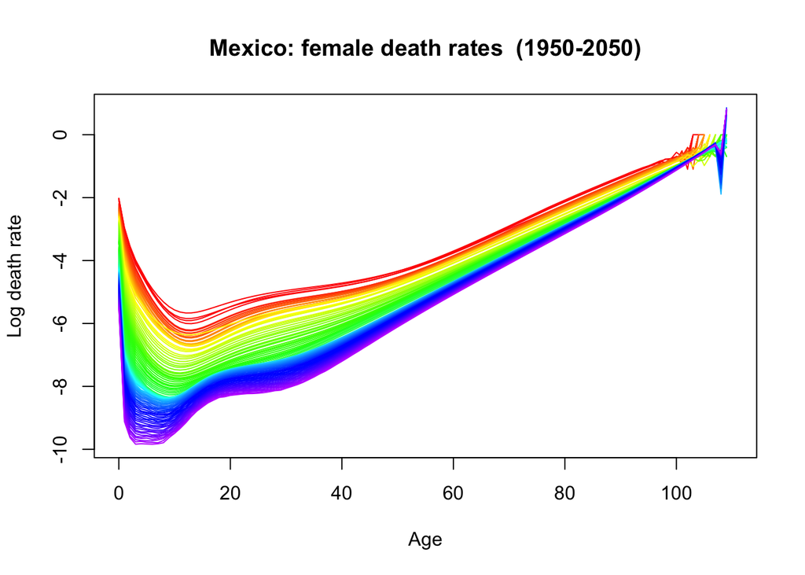

```r
plot(mex,series="Female", plot.type="functions")
```

## Creando y graficando Tabla de vida

El paquete, calcula la tabla de vida:

```r
mex.ltM <- lifetable(mex, series="male")

lt2000male <- print(lifetable(mex, series="male",year=2000))
```

```
## Period lifetable for Mexico : male
##
## Year: 2000
##         mx     qx     lx     dx     Lx      Tx      ex
## 0   0.0254 0.0249 1.0000 0.0249 0.9779 72.0458 72.0458
## 1   0.0017 0.0017 0.9751 0.0016 0.9743 71.0678 72.8803
## 2   0.0008 0.0008 0.9735 0.0008 0.9731 70.0935 72.0024
## 3   0.0006 0.0006 0.9727 0.0006 0.9724 69.1204 71.0627
## 4   0.0005 0.0005 0.9721 0.0005 0.9719 68.1481 70.1036
## 5   0.0004 0.0004 0.9716 0.0004 0.9714 67.1762 69.1369
## 6   0.0004 0.0004 0.9713 0.0004 0.9711 66.2047 68.1640
## 7   0.0004 0.0004 0.9709 0.0003 0.9707 65.2337 67.1887
## 8   0.0004 0.0004 0.9706 0.0003 0.9704 64.2629 66.2122
## 9   0.0004 0.0004 0.9702 0.0003 0.9700 63.2925 65.2352
## 10  0.0004 0.0004 0.9699 0.0004 0.9697 62.3225 64.2586
```

[output cut: 90 more lines]

```r
lt2000male
```

```
## $`2000`
##               mx           qx         lx           dx         Lx          Tx
## 0   0.0254296185 0.0248688353 1.00000000 0.0248688353 0.97794764 72.04578462
## 1   0.0016850551 0.0016836366 0.97513116 0.0016417665 0.97431028 71.06783698
## 2   0.0008441912 0.0008438350 0.97348940 0.0008214645 0.97307867 70.09352670
## 3   0.0005787986 0.0005786312 0.97266793 0.0005628160 0.97238653 69.12044803
## 4   0.0004781651 0.0004780508 0.97210512 0.0004647156 0.97187276 68.14806151
## 5   0.0003944365 0.0003943587 0.97164040 0.0003831748 0.97144881 67.17618875
## 6   0.0003649263 0.0003648597 0.97125723 0.0003543726 0.97108004 66.20473993
## 7   0.0003527407 0.0003526785 0.97090285 0.0003424165 0.97073165 65.23365989
## 8   0.0003507605 0.0003506990 0.97056044 0.0003403746 0.97039025 64.26292824
## 9   0.0003601968 0.0003601320 0.97022006 0.0003494073 0.97004536 63.29253799
## 10  0.0003799046 0.0003798325 0.96987066 0.0003683884 0.96968646 62.32249263
## 11  0.0004135281 0.0004134426 0.96950227 0.0004008335 0.96930185 61.35280617
## 12  0.0004626282 0.0004625212 0.96910143 0.0004482299 0.96887732 60.38350432
```

[output cut: 190 more lines]

```r
lt2000female <- print(lifetable(mex, series="female",year=2000))
```

```
## Period lifetable for Mexico : female
##
## Year: 2000
##         mx     qx     lx     dx     Lx      Tx      ex
## 0   0.0205 0.0201 1.0000 0.0201 0.9821 77.4163 77.4163
## 1   0.0014 0.0014 0.9799 0.0014 0.9792 76.4342 78.0033
## 2   0.0008 0.0008 0.9785 0.0008 0.9781 75.4550 77.1134
## 3   0.0005 0.0005 0.9777 0.0005 0.9775 74.4769 76.1728
## 4   0.0004 0.0004 0.9772 0.0004 0.9770 73.4995 75.2136
## 5   0.0003 0.0003 0.9768 0.0003 0.9766 72.5224 74.2454
## 6   0.0003 0.0003 0.9765 0.0003 0.9763 71.5458 73.2701
## 7   0.0003 0.0003 0.9762 0.0003 0.9761 70.5695 72.2914
## 8   0.0002 0.0002 0.9759 0.0002 0.9758 69.5934 71.3103
## 9   0.0002 0.0002 0.9757 0.0002 0.9756 68.6176 70.3279
## 10  0.0002 0.0002 0.9754 0.0002 0.9753 67.6421 69.3446
```

[output cut: 90 more lines]

```r
lt2000female
```

```
## $`2000`
##               mx           qx         lx           dx         Lx          Tx
## 0   0.0204821053 0.0201155614 1.00000000 0.0201155614 0.98210419 77.41633224
## 1   0.0014200859 0.0014190783 0.97988444 0.0013905328 0.97918917 76.43422805
## 2   0.0007744811 0.0007741813 0.97849391 0.0007575317 0.97811514 75.45503888
## 3   0.0005389734 0.0005388282 0.97773637 0.0005268319 0.97747296 74.47692374
## 4   0.0004250616 0.0004249712 0.97720954 0.0004152859 0.97700190 73.49945078
## 5   0.0003351679 0.0003351117 0.97679426 0.0003273352 0.97663059 72.52244888
## 6   0.0002926079 0.0002925651 0.97646692 0.0002856802 0.97632408 71.54581830
## 7   0.0002640796 0.0002640447 0.97618124 0.0002577555 0.97605236 70.56949422
## 8   0.0002473663 0.0002473357 0.97592349 0.0002413807 0.97580280 69.59344185
## 9   0.0002390811 0.0002390526 0.97568210 0.0002332393 0.97556549 68.61763906
## 10  0.0002409379 0.0002409089 0.97544887 0.0002349943 0.97533137 67.64207357
## 11  0.0002516579 0.0002516262 0.97521387 0.0002453894 0.97509118 66.66674220
## 12  0.0002724453 0.0002724082 0.97496848 0.0002655894 0.97483569 65.69165103
```

[output cut: 190 more lines]

## La esperanza de vida

```r
life.expectancy(mex)
```

```
## Time Series:
## Start = 1950
## End = 2050
## Frequency = 1
##     1950     1951     1952     1953     1954     1955     1956     1957
## 48.73248 48.22224 50.40206 49.84592 53.45664 54.06827 55.13301 55.47839
##     1958     1959     1960     1961     1962     1963     1964     1965
## 56.38652 57.19104 57.62616 58.72563 58.97056 59.12482 60.21253 60.44518
##     1966     1967     1968     1969     1970     1971     1972     1973
## 60.80025 61.63034 61.42456 62.25012 62.16535 63.82923 64.28356 64.75434
##     1974     1975     1976     1977     1978     1979     1980     1981
## 66.23278 66.69809 67.19527 67.99215 68.78206 69.37520 69.70615 70.41895
##     1982     1983     1984     1985     1986     1987     1988     1989
## 71.23162 71.42154 71.93352 72.07228 72.76580 73.09394 73.31912 73.49307
##     1990     1991     1992     1993     1994     1995     1996     1997
## 73.94998 74.61362 74.90931 74.88148 75.10043 75.00921 75.37532 75.85780
##     1998     1999     2000     2001     2002     2003     2004     2005
## 76.26613 76.75112 77.41633 77.68988 77.73378 77.70974 78.01113 77.80523
##     2006     2007     2008     2009     2010     2011     2012     2013
## 78.19208 78.01398 78.06226 77.87640 77.89447 78.01131 78.01395 77.97823
##     2014     2015     2016     2017     2018     2019     2020     2021
## 77.83892 77.56802 77.70406 77.75011 77.87789 77.97525 78.11031 78.23605
##     2022     2023     2024     2025     2026     2027     2028     2029
## 78.37901 78.52115 78.67105 78.82243 78.97790 79.13285 79.29012 79.44755
##     2030     2031     2032     2033     2034     2035     2036     2037
## 79.60649 79.76369 79.92149 80.07906 80.23522 80.39011 80.54409 80.69810
##     2038     2039     2040     2041     2042     2043     2044     2045
## 80.85114 81.00124 81.14905 81.29882 81.44500 81.59008 81.73348 81.87597
##     2046     2047     2048     2049     2050
## 82.01893 82.15692 82.29553 82.43329 82.56838
```

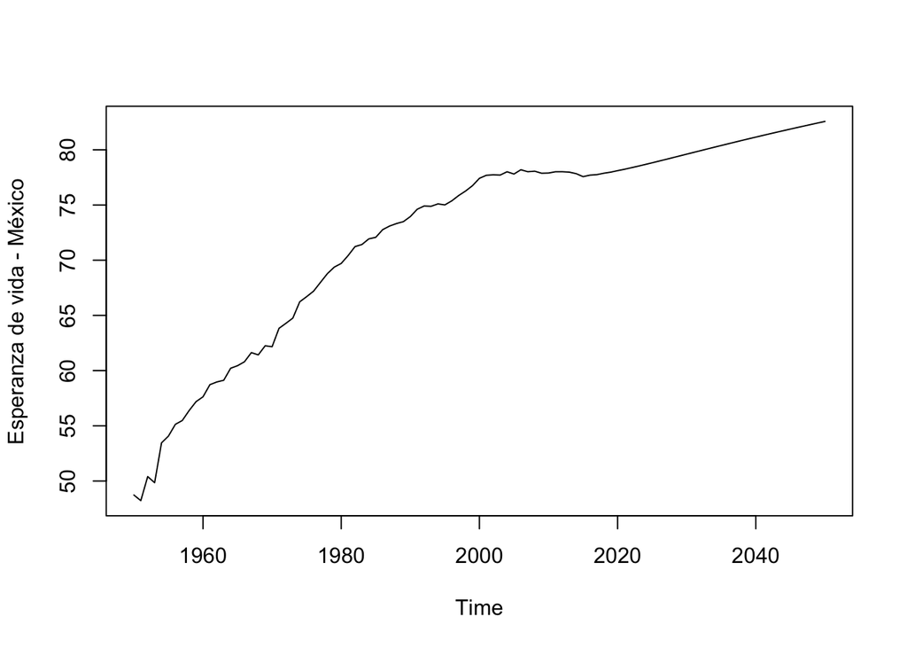

```r
plot(life.expectancy(mex),ylab="Esperanza de vida - México")
```

#Estandarización de tasas

Vamos a volver a nuestros grupos quinquenales, dejando la mortalidad infantil aparte:

```r
pob<-pob_1jul %>%
  filter(Year%in%c(1995,2015)) %>%
  mutate(eda5=cut(Age, # la variable a cortar
                  breaks=c(0,1, # para dejar la mortalidad infantil
                           seq(5,110, # El rango válido
                             by=5)), # El ancho del intervalo
                  include.lowest=T, # para que incluya el valor más bajo dentro del intervalo
                  right=F)) # indica si el intervalo irá abierto en la derecha, ponemos un no con "FALSE"
```

Vamos a volverlo quinquenal:

```r
pob<-pob %>%
  group_by(Year,eda5) %>%
    collapse::fsum() %>%
  select(-c(Age, Total)) %>%
  ungroup()

pob
```

```
## # A tibble: 46 x 4
##     Year eda5     Female    Male
##    <dbl> <fct>     <dbl>   <dbl>
##  1  1995 [0,1)   1151881 1192057
##  2  1995 [1,5)   4567696 4721962
##  3  1995 [5,10)  5545218 5695935
##  4  1995 [10,15) 5354658 5447734
##  5  1995 [15,20) 5070440 4978474
##  6  1995 [20,25) 4598901 4369818
##  7  1995 [25,30) 3957323 3745723
##  8  1995 [30,35) 3390861 3216946
##  9  1995 [35,40) 2838958 2702616
## 10  1995 [40,45) 2269799 2164863
## # … with 36 more rows
```

Lo mismo hacemos con las defunciones:

```r
def<-defunciones %>%
  filter(Year%in%c(1995,2015)) %>%
  mutate(eda5=cut(Age, # la variable a cortar
                  breaks=c(0,1, # para dejar la mortalidad infantil
                           seq(5,110, # El rango válido
                             by=5)), # El ancho del intervalo
                  include.lowest=T, # para que incluya el valor más bajo dentro del intervalo
                  right=F)) # indica si el intervalo irá abierto en la derecha, ponemos un no con "FALSE"
def<-def %>%
  group_by(Year,eda5) %>%
    collapse::fsum() %>%
  select(-c(Age, Total)) %>%
  ungroup()


def
```

```
## # A tibble: 46 x 4
##     Year eda5    Female  Male
##    <int> <fct>    <dbl> <dbl>
##  1  1995 [0,1)    28573 36648
##  2  1995 [1,5)     5086  5852
##  3  1995 [5,10)    2082  2727
##  4  1995 [10,15)   1855  3218
##  5  1995 [15,20)   2610  5964
##  6  1995 [20,25)   3051  8997
##  7  1995 [25,30)   3190 10284
##  8  1995 [30,35)   3641 10454
##  9  1995 [35,40)   4425 10384
## 10  1995 [40,45)   5354 10444
## # … with 36 more rows
```

```r
mx5<-def[,3:4]/pob[,3:4]
mx5<-cbind(pob[,1:2], mx5)
mx5
```

```
##    Year      eda5       Female         Male
## 1  1995     [0,1) 0.0248055138 0.0307434963
## 2  1995     [1,5) 0.0011134716 0.0012393154
## 3  1995    [5,10) 0.0003754586 0.0004787625
## 4  1995   [10,15) 0.0003464274 0.0005907043
## 5  1995   [15,20) 0.0005147482 0.0011979574
## 6  1995   [20,25) 0.0006634194 0.0020588958
## 7  1995   [25,30) 0.0008061005 0.0027455314
## 8  1995   [30,35) 0.0010737686 0.0032496660
## 9  1995   [35,40) 0.0015586705 0.0038422033
## 10 1995   [40,45) 0.0023587992 0.0048243238
## 11 1995   [45,50) 0.0036277700 0.0064767939
## 12 1995   [50,55) 0.0056030602 0.0090851923
## 13 1995   [55,60) 0.0086526009 0.0130400390
## 14 1995   [60,65) 0.0133623013 0.0189200692
```

[output cut: 32 more lines]

Nuestra “c” en este formato será más facil de calcular:

```r
c<-pob %>%
    group_by(Year) %>%
    mutate(c_f=Female/(sum(Female)+sum(Male)),
           c_m=Male/(sum(Female)+sum(Male))) %>%
    select(-c(Female, Male)) %>%
    rename(Female=c_f, Male=c_m) %>%
  ungroup()
```

Si “recordamos”:

$$TBM= \sum_{n=i}^{\omega}c_i*Mx_i$$

Para año 1995:

```r
mx5[1:23,3:4]*c[1:23, 3:4]
```

```
##          Female         Male
## 1  3.111039e-04 3.990248e-04
## 2  5.537657e-05 6.371680e-05
## 3  2.266890e-05 2.969168e-05
## 4  2.019731e-05 3.503771e-05
## 5  2.841778e-05 6.493626e-05
## 6  3.321941e-05 9.795968e-05
## 7  3.473284e-05 1.119726e-04
## 8  3.964335e-05 1.138236e-04
## 9  4.817957e-05 1.130614e-04
## 10 5.829456e-05 1.137147e-04
## 11 7.171951e-05 1.220658e-04
## 12 9.052315e-05 1.392145e-04
## 13 1.150866e-04 1.620793e-04
## 14 1.460522e-04 1.892559e-04
## 15 1.772137e-04 2.105747e-04
## 16 2.018425e-04 2.168353e-04
## 17 2.113259e-04 2.034974e-04
## 18 2.071558e-04 1.783025e-04
## 19 1.765060e-04 1.372873e-04
## 20 1.145095e-04 8.254222e-05
## 21 4.654637e-05 3.225037e-05
## 22 9.439930e-06 6.587263e-06
## 23 7.621627e-07 5.661780e-07
```

La suma de eso será la tasa:

```r
tbm1995<-sum(mx5[1:23,3:4]*c[1:23, 3:4])
tbm1995
```

```
## [1] 0.005044515
```

Hoy veamos para 2015:

```r
mx5[24:46,3:4]*c[24:46, 3:4]
```

```
##          Female         Male
## 24 1.153709e-04 1.472050e-04
## 25 1.864888e-05 2.271982e-05
## 26 1.100968e-05 1.397636e-05
## 27 1.311107e-05 2.160731e-05
## 28 2.155787e-05 5.027697e-05
## 29 2.787854e-05 8.678361e-05
## 30 3.095235e-05 1.023175e-04
## 31 3.602043e-05 1.031251e-04
## 32 4.715372e-05 1.096023e-04
## 33 6.591796e-05 1.318194e-04
## 34 8.928056e-05 1.594673e-04
## 35 1.197632e-04 1.949273e-04
## 36 1.549266e-04 2.320355e-04
## 37 1.884418e-04 2.596751e-04
## 38 2.245035e-04 2.833096e-04
## 39 2.632186e-04 3.017195e-04
## 40 2.939237e-04 3.018349e-04
## 41 3.012580e-04 2.749452e-04
## 42 2.619825e-04 2.125214e-04
## 43 1.793028e-04 1.300147e-04
## 44 8.425369e-05 5.574061e-05
## 45 2.263741e-05 1.409997e-05
## 46 2.406307e-06 1.458617e-06
```

La tasa bruta de mortalidad bruta será:

```r
tbm2015<-sum(mx5[24:46,3:4]*c[24:46, 3:4])
tbm2015
```

```
## [1] 0.005784703
```

Una estandarización sería usar la “c” de una de las poblaciones, como la de 2015

```r
tnm_95_15<-sum(mx5[1:23,3:4]*c[24:46, 3:4]) # 1995 con la c de 2015
tnm_95_15
```

```
## [1] 0.006625538
```

Para estandarizar, cambiamos las “c”, normalmente lo que se hace usar una $\bar c$:

```r
c_barra<-c[24:46, 3:4]/2+c[1:23, 3:4]/2
c_barra
```

```
##          Female         Male
## 1  1.075456e-02 1.113715e-02
## 2  4.286865e-02 4.433802e-02
## 3  5.280407e-02 5.443292e-02
## 4  5.182136e-02 5.309951e-02
## 5  5.008906e-02 5.017767e-02
## 6  4.734724e-02 4.628008e-02
## 7  4.273261e-02 4.074963e-02
## 8  3.819844e-02 3.546113e-02
## 9  3.398477e-02 3.115511e-02
## 10 2.969581e-02 2.751493e-02
## 11 2.509405e-02 2.343732e-02
## 12 2.111032e-02 1.967760e-02
## 13 1.739314e-02 1.603731e-02
## 14 1.377907e-02 1.247925e-02
## 15 1.059918e-02 9.355852e-03
## 16 7.887562e-03 6.703358e-03
## 17 5.533982e-03 4.471597e-03
## 18 3.608049e-03 2.753594e-03
## 19 2.024805e-03 1.459570e-03
## 20 8.744203e-04 5.964732e-04
## 21 2.494424e-04 1.631770e-04
## 22 3.906831e-05 2.499047e-05
## 23 2.494071e-06 1.608209e-06
```

Vamos a sacar las tasas estandarizadas.

```r
tnm1995<-sum(mx5[mx5$Year==1995,3:4]*c_barra) # 1995
tnm1995
```

```
## [1] 0.005835027
```

```r
tnm2015<-sum(mx5[mx5$Year==2015,3:4]*c_barra) # 2015
tnm2015
```

```
## [1] 0.005011785
```

¡Es muy importante estandarizar!

## Discrepancias

¿Qué parte de la diferencia de las tasas se debe al cambio etario y cuál al cambio de los riesgos de morir? Siguiendo a Kitagawa en Partida(2013), tenemos:

$$d^{2015}-d^{1995}= \sum_{n=i}^{\omega}(c_i^{2015}-c_i^{1995})\frac{(Mx_i^{2015}+Mx_i^{1995})}2 + \sum_{n=i}^{\omega}(Mx_i^{2015}-Mx_i^{1995})\frac{(c_i^{2015}+c_i^{1995})}2$$

> El primer sumando en el lado derecho, esto es, la diferencia de las estructuras etarias ponderada por el promedio de las tasas específicas, mide el efecto de la disimiltud en las composiciones por edad; y el segundo, la diferencia de las pautas etarias de las tasas específicas ponderada por el promedio de las composiciones por edad de la población, da cuenta de la diferencia en el riesgo medio de morir (Partida,2013:p.63).

```r
diff<-tbm2015-tbm1995
diff
```

```
## [1] 0.0007401877
```

Caculemos el primer elemento

```r
(c[24:46, 3:4]-c[1:23, 3:4])*((mx5[mx5$Year==2015,3:4]+mx5[mx5$Year==1995,3:4])/2)
```

```
##           Female          Male
## 1  -6.732460e-05 -8.580133e-05
## 2  -1.119917e-05 -1.308167e-05
## 3  -4.686346e-06 -5.893984e-06
## 4  -4.118874e-06 -6.536192e-06
## 5  -5.088002e-06 -9.213951e-06
## 6  -3.511340e-06 -5.179360e-06
## 7  -5.452632e-07 -1.785234e-07
## 8   2.539588e-06  2.662681e-06
## 9   8.702948e-06  1.240536e-05
## 10  2.122225e-05  3.555174e-05
## 11  3.494363e-05  5.585183e-05
## 12  5.052356e-05  7.487929e-05
## 13  6.491822e-05  8.966228e-05
## 14  7.035412e-05  8.984928e-05
## 15  7.614960e-05  8.993061e-05
## 16  8.974491e-05  9.922147e-05
## 17  1.080676e-04  1.089427e-04
## 18  1.147847e-04  1.034555e-04
## 19  9.884585e-05  7.844997e-05
## 20  7.079305e-05  4.825506e-05
## 21  3.896147e-05  2.324977e-05
## 22  1.312133e-05  7.303442e-06
## 23  1.592063e-06  8.523531e-07
```

```r
desc_1 <-sum((c[24:46, 3:4]-c[1:23, 3:4])*((mx5[mx5$Year==2015,3:4]+mx5[mx5$Year==1995,3:4])/2))
desc_1
```

```
## [1] 0.00156343
```

El segundo elemento:

```r
(mx5[mx5$Year==2015,3:4]-mx5[mx5$Year==1995,3:4])*c_barra
```

```
##           Female          Male
## 24 -1.284085e-04 -1.660185e-04
## 25 -2.552852e-05 -2.791532e-05
## 26 -6.972875e-06 -9.821343e-06
## 27 -2.967364e-06 -6.894203e-06
## 28 -1.771910e-06 -5.445340e-06
## 29 -1.829522e-06 -5.996716e-06
## 30 -3.235227e-06 -9.476597e-06
## 31 -6.162507e-06 -1.336117e-05
## 32 -9.728802e-06 -1.586444e-05
## 33 -1.359884e-05 -1.744697e-05
## 34 -1.738257e-05 -1.845039e-05
## 35 -2.128352e-05 -1.916645e-05
## 36 -2.507821e-05 -1.970610e-05
## 37 -2.796446e-05 -1.943009e-05
## 38 -2.885987e-05 -1.719565e-05
## 39 -2.836876e-05 -1.433724e-05
## 40 -2.546984e-05 -1.060530e-05
## 41 -2.068250e-05 -6.812758e-06
## 42 -1.336935e-05 -3.215888e-06
## 43 -5.999761e-06 -7.825651e-07
## 44 -1.254143e-06  2.404676e-07
## 45  7.615186e-08  2.092621e-07
## 46  5.208082e-08  4.008614e-08
```

```r
desc_2<-sum((mx5[mx5$Year==2015,3:4]-mx5[mx5$Year==1995,3:4])*c_barra)
desc_2
```

```
## [1] -0.000823242
```

```r
desc_1+desc_2
```

```
## [1] 0.0007401877
```

#Ejercicio

1. con otro estado que no sea la República Mexicana, y presente todo el código y los resultados hasta la Esperanza de Vida en México.
2. Compare las tasas de mortalidad de ese mismo estado entre 2005 y 2015, usando las tasas estandarizadas de mortalidad.

Envíe los resultados por acá: https://forms.gle/6LXmG59AZiTWmDtH7